# Análise do Consumo de Combustível - Aerometrics

Levi Gurgel de Lima, Yves Gabriel Queiroz de Sousa e Marco Aurélio Costa Risardi

Este relatório apresenta o processo de preparação, exploração e modelagem dos dados históricos de voo utilizados pela **Aerometrics** para prever o consumo de combustível em operações aéreas. O objetivo é desenvolver modelos preditivos capazes de auxiliar companhias aéreas na tomada de decisões estratégicas, aumentando a eficiência e reduzindo custos operacionais.

```r
# setwd("C:/Users/levid/OneDrive/Desktop/GitHub/plane-fuel")

# Pacotes úteis
library(tidyverse)
library(lubridate)
library(e1071)
library(neuralnet)
library(caret)
library(tree)

# Defina o seed para reprodutibilidade
set.seed(123)

# Carregar bases
load("data_project_train.Rda")
load("data_project_test.Rda")
```

```r
# Conferir estrutura
summary(data_train)
```

```
   flight_id              orig           dest         dep_time
 Min.   :785929656   SBSP   :1239   SBGR   :1407   Min.   :2023-01-14 00:01:24.00
 1st Qu.:797507106   SBGR   :1104   SBSP   :1377   1st Qu.:2023-03-15 21:06:47.50
 Median :822383588   SBRJ   : 728   SBRJ   : 743   Median :2023-07-06 12:20:44.00
 Mean   :821981147   SBBR   : 626   SBBR   : 697   Mean   :2023-07-01 09:03:27.11
 3rd Qu.:848453636   SBSV   : 313   SBSV   : 311   3rd Qu.:2023-10-25 00:28:12.00
 Max.   :861779696   SBPA   : 302   SBCF   : 282   Max.   :2023-12-24 23:57:44.00
                     (Other):2967   (Other):2462
    arr_time                      airline    aircraft_type flown_distance_enr flight_duration
 Min.   :2023-01-14 00:47:01.00   GLO:3209   A319: 901     Min.   :  91.31    Min.   : 31.68
 1st Qu.:2023-03-15 22:33:25.00   TAM:4070   A320:1966     1st Qu.: 191.47    1st Qu.: 52.01
 Median :2023-07-06 13:55:54.00              A321:1203     Median : 390.36    Median : 78.72
 Mean   :2023-07-01 10:32:54.76              B737: 542     Mean   : 474.29    Mean   : 89.46
 3rd Qu.:2023-10-25 01:39:13.50              B738:2667     3rd Qu.: 657.13    3rd Qu.:114.31
 Max.   :2023-12-25 02:28:28.00                            Max.   :1671.72    Max.   :254.75

 kpi_inefficiency_dep kpi_inefficiency_enr kpi_inefficiency_arr   fuel_burn
 Min.   : 0.0000      Min.   :  0.00572    Min.   : 0.00000     Min.   : 1517
 1st Qu.: 0.0000      1st Qu.:  3.06458    1st Qu.: 0.06667     1st Qu.: 2583
 Median : 0.0000      Median :  6.99902    Median : 1.32667     Median : 3822
 Mean   : 0.1621      Mean   : 11.96367    Mean   : 2.61064     Mean   : 4569
 3rd Qu.: 0.0000      3rd Qu.: 16.54192    3rd Qu.: 3.31667     3rd Qu.: 5737
 Max.   :10.9500      Max.   :249.07762    Max.   :54.42667     Max.   :21029
```

# Feature Engineering

Nesta etapa realizamos a criação de novas variáveis derivadas das informações brutas do dataset.  
A engenharia de atributos é fundamental para melhorar a representação dos dados e aumentar o poder preditivo dos modelos.

As principais transformações incluem:

- **Velocidade média (avg_speed)**: estimada pela razão entre distância voada e tempo de voo.
- **Indicadores de eficiência**: métricas de consumo por milha náutica e por minuto.
- **Classificação do tipo de rota**: segmentação dos voos em *curto*, *médio* ou *longo alcance*.
- **Variáveis temporais**: extração da hora de partida e do período do dia (*manhã*, *tarde*, *noite*).
- **Índice total de ineficiência operacional**: combinação dos KPIs de decolagem e pouso.

Esses atributos aprimoram a capacidade dos modelos em capturar padrões relevantes associados ao consumo de combustível.

```r
df_train <- data_train %>%
  mutate(
    avg_speed = flown_distance_enr / (flight_duration / 60),        # NM/h
    fuel_per_nm = fuel_burn / flown_distance_enr,
    fuel_per_min = fuel_burn / flight_duration,
    total_ineff = kpi_inefficiency_dep + kpi_inefficiency_arr,
    flight_range = case_when(
      flown_distance_enr < 400 ~ "Curto",
      flown_distance_enr < 800 ~ "Médio",
      TRUE ~ "Longo"
    ),
    flight_range = factor(flight_range, levels = c('Curto', 'Médio', 'Longo')),
    dep_hour = hour(dep_time),
    dep_period = case_when(
      dep_hour >= 5 & dep_hour < 12 ~ "Manhã",
      dep_hour >= 12 & dep_hour < 18 ~ "Tarde",
      TRUE ~ "Noite"
    ),
    dep_period = factor(dep_period, levels = c("Manhã", "Tarde", "Noite"))
  )
```

```r
# Aplicar o mesmo processo à base de teste (sem fuel_burn)
df_test <- data_test %>%
  mutate(
    avg_speed = flown_distance_enr / (flight_duration / 60),
    total_ineff = kpi_inefficiency_dep + kpi_inefficiency_arr,
    flight_range = case_when(
      flown_distance_enr < 400 ~ "Curto",
      flown_distance_enr < 800 ~ "Médio",
      TRUE ~ "Longo"
    ),
    flight_range = factor(flight_range, levels = c('Curto', 'Médio', 'Longo')),
    dep_hour = hour(dep_time),
    dep_period = case_when(
      dep_hour >= 5 & dep_hour < 12 ~ "Manhã",
      dep_hour >= 12 & dep_hour < 18 ~ "Tarde",
      TRUE ~ "Noite"
    ),
    dep_period = factor(dep_period, levels = c("Manhã", "Tarde", "Noite"))
  )
```

# Análise Exploratória dos Dados

A análise exploratória visa compreender o comportamento das variáveis do conjunto de treinamento e identificar padrões importantes relacionados ao consumo de combustível.

Nesta etapa, avaliamos:

- A distribuição do **tempo de voo** e sua relação com as operações.
- O comportamento da variável **hora de partida**, essencial para identificar efeitos diurnos e operacionais.
- A distribuição da **distância voada**, que geralmente tem grande impacto no consumo.
- A variabilidade do **fuel_burn**, analisada tanto por histogramas quanto por agrupamentos por tipo de aeronave.

Essas visualizações oferecem uma visão geral da dispersão, não linearidades e possíveis outliers presentes nos dados.

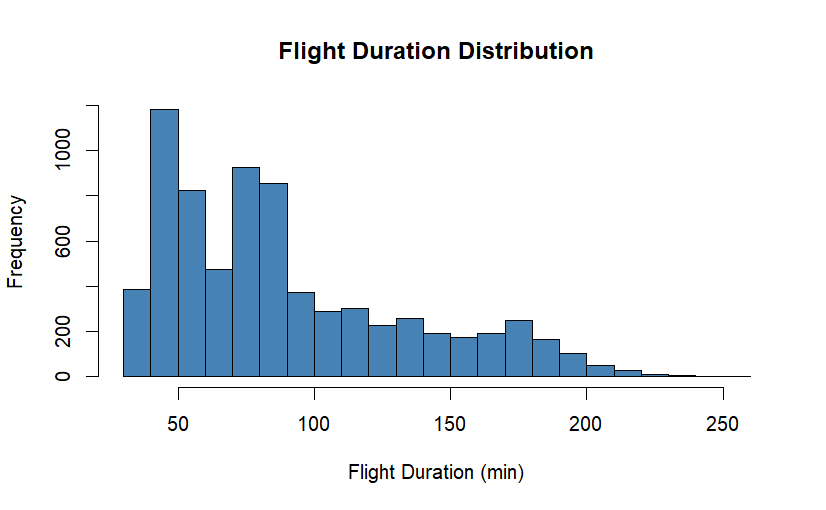

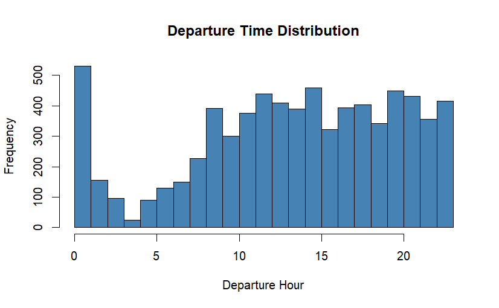

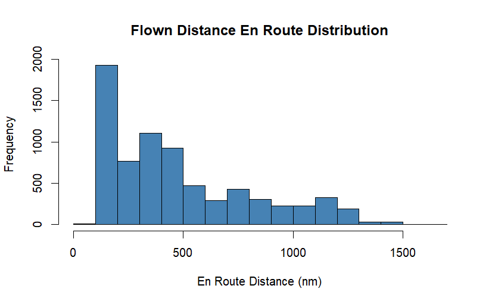

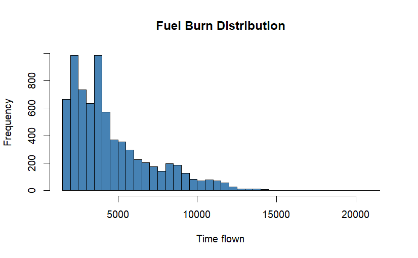

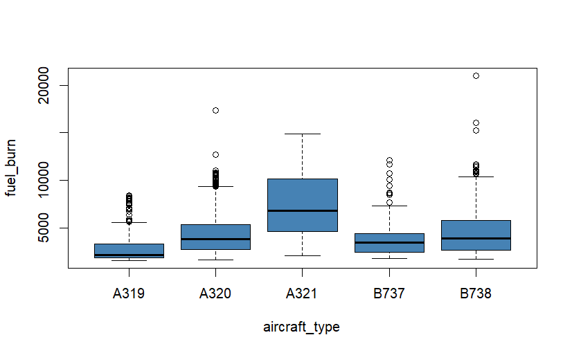

# Modelo de Rede Neural

A Aerometrics utilizou uma rede neural simples com função de ativação *tanh* para prever consumo de combustível em escala logaritimizada.  
Os componentes principais obtidos pelo PCA serviram como entrada para o modelo, reduzindo complexidade e melhorando estabilidade.

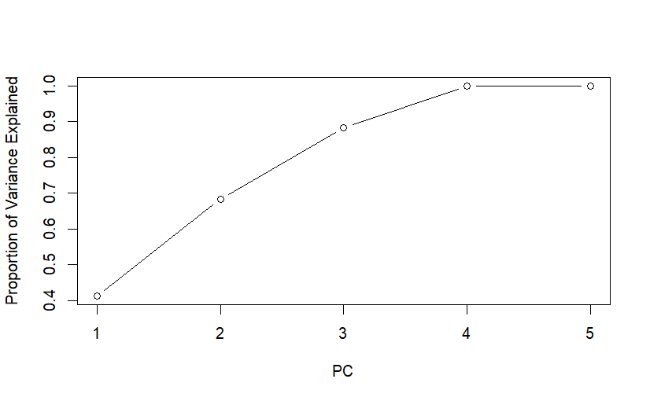

```r
# PCA
x <- subset(data_train, select=c(8:12))

pca_out <- prcomp(x, scale=TRUE)

var_explained_pc <- pca_out$sdev^2
pve <- var_explained_pc/sum(var_explained_pc)

plot(cumsum(pve), xlab='PC',
     ylab='Proportion of Variance Explained', type='b')
```

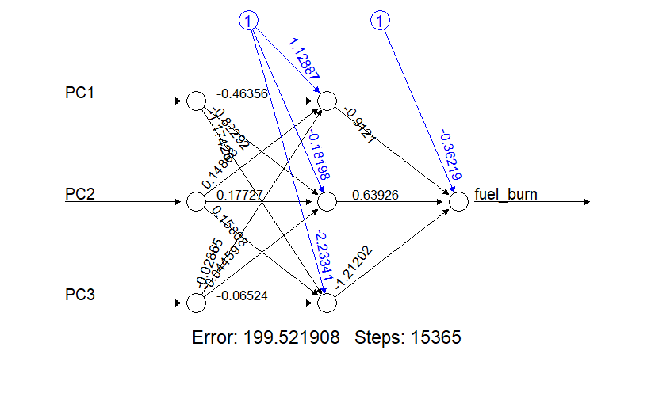

```r
data_train_pc <- data.frame(pca_out$x)
data_train_pc$fuel_burn <- data_train$fuel_burn %>% log1p() %>%
                            scale() %>% as.numeric()

# Rodar o modelo
nn_model <- neuralnet(
  fuel_burn ~ PC1 + PC2 + PC3,
  data = data_train_pc,
  hidden = c(3),
  act.fct = 'tanh',
  linear.output = TRUE,
  threshold = 0.1
)

plot(nn_model)
```

```r
pred <- compute(nn_model, data_train_pc[, 1:3])$net.result
y_true <- data_train$fuel_burn
y_pred_nn <- expm1(pred * sd(log1p(y_true)) + mean(log1p(y_true)))

RMSE <- mean(abs(y_pred_nn - y_true)/y_true)
cat("RMSE =", RMSE)
```

```
RMSE = 0.08930377
```

# Modelo de Árvore de Decisão

Também treinamos um modelo baseado em árvore de decisão, que permite interpretar a influência das variáveis de forma mais direta e intuitiva.  
Esse método é útil para capturar relações não lineares e interações entre atributos operacionais.

A validação cruzada foi utilizada para auxiliar na escolha de profundidades mais adequadas da árvore.

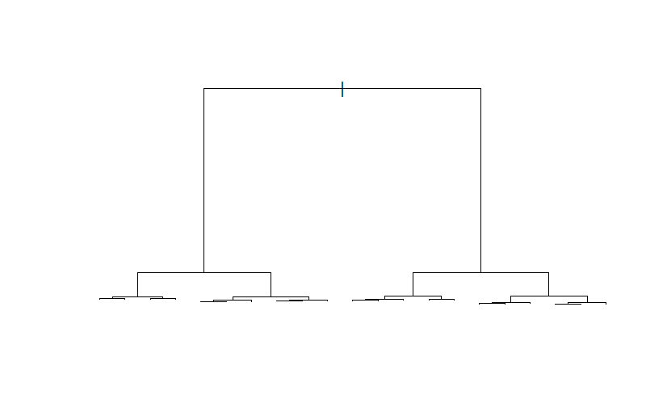

```r
library(tree)

tree_model <- tree(fuel_burn ~ airline + aircraft_type + flown_distance_enr +
                     flight_duration + total_ineff + flight_range + dep_hour,
                   df_train,
                   mindev=0.001)

plot(tree_model)
```

```r
# text(tree_model)
```

```r
summary(tree_model)
```

```
Regression tree:
tree(formula = fuel_burn ~ airline + aircraft_type + flown_distance_enr +
    flight_duration + total_ineff + flight_range + dep_hour,
    data = df_train, mindev = 0.001)
Variables actually used in tree construction:
[1] "flown_distance_enr" "flight_duration"    "aircraft_type"
Number of terminal nodes:  21
Residual mean deviance:  188000 = 1.364e+09 / 7258
Distribution of residuals:
    Min.  1st Qu.   Median     Mean  3rd Qu.     Max.
-1940.00  -225.00   -12.96     0.00   199.30 10350.00
```

```r
y_pred_dt <- predict(tree_model, df_train)

y_true <- data_train$fuel_burn
RMSE <- mean(abs(y_pred_dt - y_true)/y_true)
print(RMSE)
```

```
[1] 0.06900043
```

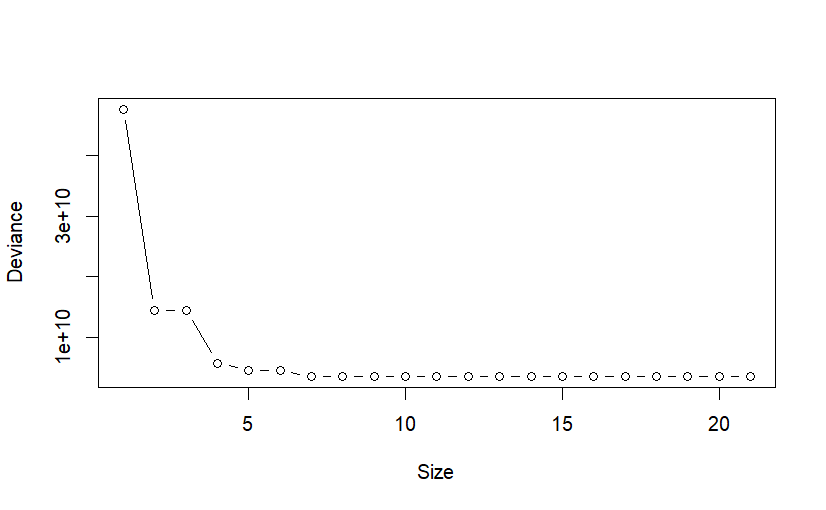

```r
set.seed(1)
cv_results <- cv.tree(tree_model, FUN=prune.tree, K=10)

plot(cv_results$size, cv_results$dev, ylab='Deviance', xlab='Size', type='b')
```

```r
# idx <- cv_results$size >= 7
#
# plot(cv_results$size[idx], cv_results$dev[idx],
#      ylab='Deviance', xlab='Size', type='b')
```

```r
data_train$prediction_nn <- as.numeric(y_pred_nn)
data_train$prediction_dt <- y_pred_dt
```

# Ensemble: Combinação dos Modelos

Com o objetivo de melhorar a capacidade preditiva final, foi criado um modelo *ensemble* linear combinando:

- as previsões da **rede neural**, e
- as previsões da **árvore de decisão**.

Esse método geralmente proporciona maior robustez e menor variância preditiva.

```r
df_ensemble <- data.frame(
  fuel_burn = data_train$fuel_burn,
  nn = data_train$prediction_nn,
  dt = data_train$prediction_dt
)
```

```r
model_ensemble <- lm(fuel_burn ~ nn + dt, data = df_ensemble)
summary(model_ensemble)
```

[output not shown]

```r
coef(model_ensemble)
```

[output not shown]

```r
data_train$prediction_ensemble <- predict(model_ensemble, df_ensemble)

rmse <- mean(abs(data_train$fuel_burn - data_train$prediction_ensemble)/data_train$fuel_burn)
print(rmse)
```

[output not shown]

# Previsão Final no Conjunto de Teste

Após treinar e calibrar os modelos no conjunto de treinamento, aplicamos o pipeline completo ao conjunto de teste:

1. Aplicação do mesmo *feature engineering* utilizado no treino.
2. Projeção dos dados no espaço do PCA.
3. Predição individual pelos modelos (NN e DT).
4. Combinação final pelo ensemble.

O resultado é uma estimativa consistente e otimizada do consumo de combustível, pronta para ser utilizada pelos sistemas internos da Aerometrics.

```r
# Média e desvio padrão usados no treino (salvos quando você normalizou o y)
mean_train <- mean(log1p(data_train$fuel_burn), na.rm = TRUE)
sd_train   <- sd(log1p(data_train$fuel_burn), na.rm = TRUE)

# Usa o mesmo PCA treinado no data_train
x_test <- subset(data_test, select = c(8:12))
data_test_pc <- predict(pca_out, newdata = x_test) |> as.data.frame()

# Se o modelo neural espera um campo fuel_burn (mesmo que não use na previsão)
data_test_pc$fuel_burn <- (log1p(data_test$fuel_burn) - mean_train) / sd_train

# Rede neural (em escala padronizada)
y_test_scaled <- as.numeric(predict(nn_model, data_test_pc))

# Reverter escala (desfaz o log1p e a normalização do treino)
y_pred_nn <- as.numeric(expm1(y_test_scaled * sd_train + mean_train))

# Árvore de decisão
y_pred_dt <- predict(tree_model, df_test)

# Pegar os coeficientes do ensemble treinado no data_train
w <- coef(model_ensemble)

# Calcular previsão final ponderada
prediction_nn <- y_pred_nn
prediction_dt <- y_pred_dt

data_test$fuel_burn <- w["nn"] * prediction_nn +
                                 w["dt"] * prediction_dt
```

Por fim, salvamos o arquivo final contendo as previsões de combustível processadas pelo ensemble Aerometrics.

```r
save(data_test, file = "data_project_test_aerometrics.Rda")
```